# M2: Assignment 1

**Loading libraries**

```r
rm(list = ls()) # Clearing the environment
library(data.table)
library(magrittr)
library(tidyverse)
library(tidygraph)
library(ggraph)
library(igraph)
```

#### Loading the data by *fread*, and adding columnnames

Loading the attributes data.

```r
attributes <- fread("https://raw.githubusercontent.com/SDS-AAU/SDS-master/master/00_data/network_krackhard/Krack-High-Tec-Attributes.csv")
attributes %>% head() # Inspecting the data.
```

[output not shown]

From the inspection of the data, I will change the columnnames to lower case characters, to make it easier to call the columns, and make them less aggressive.

```r
colnames(attributes) %<>% # The pipe selects the data and saves the changes to the data.
  tolower() # The columnnames are selected, so tolower can be used to change the characters to lower case letters.
```

Loading the advice edgelist.

```r
advice <- fread("https://raw.githubusercontent.com/SDS-AAU/SDS-master/master/00_data/network_krackhard/Krack-High-Tec-edgelist-Advice.txt", col.names = c("from", "to", "edge"))
glimpse(advice)
```

[output not shown]

Loading the friendship edgelist.

```r
friendship <- fread("https://raw.githubusercontent.com/SDS-AAU/SDS-master/master/00_data/network_krackhard/Krack-High-Tec-edgelist-Friendship.txt", col.names = c("from", "to", "edge"))
```

Loading the reports-to edgelist.

```r
reportsto <- fread("https://raw.githubusercontent.com/SDS-AAU/SDS-master/master/00_data/network_krackhard/Krack-High-Tec-edgelist-ReportsTo.txt", col.names = c("from", "to", "edge"))
```

The edgelists need to be prepared before they can be used. This is done by dropping every row, where an edge is not present, since the pair of individuals do not have a directed social relationship. Furthermore it is not really too interesting for the analysis if there is a loop, i.e. the individual has a social connection with themself, so these rows, if any, are dropped.

```r
advice %<>%
  filter(edge == 1 & from != to)   # Only using rows where edge == 1 and where from =/= to.
advice %>% head()
```

| from | to | edge |
| --- | --- | --- |
| 1 | 2 | 1 |
| 1 | 4 | 1 |
| 1 | 8 | 1 |
| 1 | 16 | 1 |
| 1 | 18 | 1 |
| 1 | 21 | 1 |

Great, now the edgelist only contains individuals with a connection. The edge column can therefore be dropped.

```r
advice %<>%
  select(-edge)
```

The procedure is repeated for the other two edgelists.

```r
friendship %<>%
  filter(edge == 1 & from != to) %>%
  select(-edge)
reportsto %<>%
  filter(edge == 1 & from != to) %>%
  select(-edge)
```

## 1. Creating network objects

It is more meaningful to create a directed network, where the direction of the edges have meaning, because the social relationships are not per definition reciprocal between the parties. For instance, if person A reports to person B, person B might not report to person A, and thus an undirected network would be leaving out important information.

Creating the “advice” dimension of the network. This is first done by creating the graph object using **igraph**, and then converting to a *tbl_graph* object using* **tidygraph**.

```r
g_adv <- graph_from_data_frame(advice, vertices = attributes, directed = TRUE) %>% # Directed igraph object using the attributes as a nodelist.
  as_tbl_graph(directed = TRUE) %E>% # Converting to tbl_graph object.
  mutate(type = "advice") # Specifying the edgetype for later.
g_adv
```

```
## # A tbl_graph: 21 nodes and 190 edges
## #
## # A directed simple graph with 1 component
## #
## # Edge Data: 190 x 3 (active)
##    from    to type
##   <int> <int> <chr>
## 1     1     2 advice
## 2     1     4 advice
## 3     1     8 advice
## 4     1    16 advice
## 5     1    18 advice
## 6     1    21 advice
## # ... with 184 more rows
## #
## # Node Data: 21 x 5
##   name    age tenure level  dept
##   <chr> <int>  <dbl> <int> <int>
## 1 1        33   9.33     3     4
## 2 2        42  19.6      2     4
## 3 3        40  12.8      3     2
## # ... with 18 more rows
```

The network consists of 21 nodes and 190 edges. The node data can be seen to be attached to the corresponding id’s or names.

Creating the “friendship” dimension of the network.

```r
g_friend <- graph_from_data_frame(friendship, vertices = attributes, directed = TRUE) %>%
  as_tbl_graph(directed = TRUE) %E>%
  mutate(type = "friend")
```

Creating the “reports to” dimension of the network.

```r
g_rep_to <-
  graph_from_data_frame(reportsto, vertices = attributes, directed = TRUE) %>%
  as_tbl_graph(directed = TRUE) %E>%
  mutate(type = "reports to")
```

The network dimensions are now ready for the analysis.

## 2

### 2A. Network Level Characteristics

Initially I will calculate the density, transistivity and reciprocity of each of the networks. The density expresses the share of the possible node connections, that are present in the network. The transitivity measures how nodes tend to cluster together in the network. A higher transistivity, or clustering coefficient, equates a more clustered network. The reciprocity is a measure of how likely an edge going from A to B is to be reciprocated, i.e. go from B to A. The metrics of the network are to be calculated using functions from **igraph**. The density of the network can be calculated by *edge_density*.

```r
edge_density(g_adv)
```

```
## [1] 0.452381
```

The density of the advice network was 45.2%.

```r
edge_density(g_friend)
```

```
## [1] 0.2428571
```

The friendship network had a density of 24.3%.

```r
edge_density(g_rep_to)
```

```
## [1] 0.04761905
```

The “reports to” network was the least dense of the three with a density of 4.8%. This is also rather intuitive, since it is inefficient for everyone to be reporting to everyone in the network. It is also nice to see that advice is not necessarily between friends, since the advice network is significantly more dense than the friendship network. The transitivity can be calculated using *transitivity*.

```r
transitivity(g_adv, type = "global") # Calculating the transitivity of the entire network.
```

```
## [1] 0.7345088
```

The transitivity in the advice network was 73.5%, meaning that the network is rather highly clustered.

```r
transitivity(g_friend, type = "global")
```

```
## [1] 0.4714946
```

The transitivity in the friendship network was 47.1%. Seeing how the density and the transitivity is much higher in the advice network, than the friendship network, it can be concluded that employees are *more likely* to be in an adviceseeking relationship, than a friendship. Since the transitivity is “only” 47%, it can be concluded that friends of your friends are *not* also your friends, as that would indicate a “closed triplet”. Only with a transitivity of 1 could it be guaranteed that the friends of your friends are also your friends.

```r
transitivity(g_rep_to, type = "global")
```

```
## [1] 0
```

There is no transitivity in the “reports to” network, meaning there are no closed triplets in the network. This makes sense, as the reports go up the corporate ladder, and it would be very inefficient for individuals to be reporting in a circular manner.

The reciprocity can be calculated using *reciprocity*.

```r
reciprocity(g_adv)
```

```
## [1] 0.4736842
```

The reciprocity of advice giving is 47%, meaning that the in 47% of the cases, the person receives advice from the same person that they give advice. As it is more likely that the person does not go for advice from the person they provide advice, advice giving relationships are usually *not* reciprocal.

```r
reciprocity(g_friend)
```

```
## [1] 0.4509804
```

The reciprocity of friendship is sadly only 45%, meaning that the friendships usually are not reciprocal.

```r
reciprocity(g_rep_to)
```

```
## [1] 0
```

The reciprocity of the “reporting to” relationships are 0, which is the expected outcome, as it would be odd to be reporting down the corporate ladder

### 2B. Node level characteristics

To find the person who is the most popular in the network, I will be investigating the degree centrality. This is usually measured by the amount of edges a node has, but since the edges are directed, the degree centrality has to distinguish betwen edges going “in” or “out”, i.e. is the node the alter or the ego of the edge. To evaluate who is the most popular we will have to count the alters, since this reveals who considers the ego a friend, and the ego with the most alters will therefore be the most popular friend.

Calculating the degree centrality with the mode “in”.

```r
g_friend <- g_friend %N>% # Selecting the node level of the friendship graph.
  mutate(cent_dgr_in = centrality_degree(mode = "in")) # Creating a new variable for the degree centralities.
```

The degree centrality is stored on the node-level of the graph object, along with all the other node characteristics. Let’s explore the results. Since the “name” in our data is less than memorable, I also include some of the other information.

```r
g_friend %N>%
  select(name, level, age, tenure, cent_dgr_in) %>% # Selecting name, employment level, age, tenure and degree centrality.
  arrange(desc(cent_dgr_in)) %>% # Rearranging by descending degree centrality.
  as_tibble() %>%
  head()
```

| name | level | age | tenure | cent_dgr_in |
| --- | --- | --- | --- | --- |
| 2 | 2 | 42 | 19.583 | 10 |
| 1 | 3 | 33 | 9.333 | 8 |
| 12 | 3 | 34 | 8.917 | 8 |
| 5 | 3 | 32 | 3.333 | 6 |
| 9 | 3 | 62 | 5.417 | 6 |
| 11 | 3 | 46 | 27.000 | 6 |

From the centrality degrees we can see that the person with id “2”, is the person with the highest in-centrality degree, meaning that they are considered as a friend by the most people. 10 people consider this person as their friend, let’s see if it is reciprocated.

```r
friendship %>% filter(from == 2) # Only using rows where 2 is the ego.
```

| from | to |
| --- | --- |
| 2 | 1 |
| 2 | 18 |
| 2 | 21 |

Our most popular person does not consider many to be their friend, and the friendships are therefore generally not reciprocated. How about the most sought after advice giver? I will again be using the in-centrality degree, as we are looking for the most wanted advice *giver*, which again is revealed by the person the most people ask for advice, i.e. the highest number of edges leading to the node. I reuse the same code for the advice graph.

```r
g_adv <- g_adv %N>%
  mutate(cent_dgr_in = centrality_degree(mode = "in"))

g_adv %N>%
  select(name, level, age, tenure, cent_dgr_in) %>%
  arrange(desc(cent_dgr_in)) %>%
  as_tibble() %>%
  head()
```

| name | level | age | tenure | cent_dgr_in |
| --- | --- | --- | --- | --- |
| 2 | 2 | 42 | 19.583 | 18 |
| 18 | 2 | 33 | 9.083 | 15 |
| 21 | 2 | 36 | 12.500 | 15 |
| 1 | 3 | 33 | 9.333 | 13 |
| 7 | 1 | 55 | 30.000 | 13 |
| 11 | 3 | 46 | 27.000 | 11 |

Again, person “2” has 18 people coming to him/her for advice, and is therefore to be considered the most popular. meaning the person has the most people coming to them for advice. This person is a vice president, and has almost 20 years of service/tenure. The print only shows two managers in the top 6, so maybe people are more likely to seek advice from managers higher up the corporate ladder, or maybe those in higher hierarchy are better advice givers, and therefore more sought after. Let’s explore. This is done by calculating the mean of the degree centrality for each of the 3 levels; manager (3), VP (2) and CEO (1).

```r
g_adv %N>%
  as_tibble() %>% # Converting to a tibble object, as summarise is not applicable to a graph object.
  group_by(level) %>% # Grouping the following operation(s) by the level.
  mutate(level = recode(level, "1" = "CEO", "2" = "VP", "3" = "manager")) %>% # Recoding the levels to make the table more intuitive.
  summarise(Mean = mean(cent_dgr_in)) %>% # Summarising the mean of the centrality degrees.
  arrange(desc(Mean)) # Sorting the table by mean in descending order.
```

| level | Mean |
| --- | --- |
| VP | 14.5000 |
| CEO | 13.0000 |
| manager | 7.4375 |

VP’s are generally much more sought after for advice, and ~15 people go to them for advice on average. The CEO is also more popular as advice giver than the managers. The managers higher in the hierarchy are generally more popular for advice giving. Are managers in higher hierarchy more sought after as friends?

```r
g_friend %N>%
  as_tibble() %>% # Converting to a tibble object, as summarise is not applicable to a graph object.
  group_by(level) %>% # Grouping the following operation(s) by the level.
  mutate(level = recode(level, "1" = "CEO", "2" = "VP", "3" = "manager")) %>%
  summarise(Mean = mean(cent_dgr_in)) %>% # Summarising the mean of the centrality degrees.
  arrange(desc(Mean))
```

| level | Mean |
| --- | --- |
| VP | 6.0000 |
| manager | 4.6875 |
| CEO | 3.0000 |

The VP’s are considered friends by more people than the managers, but the CEO is only considered a friend by 3 people. Seeing how there is only one CEO in the data, it is difficult to generalize the result. Let’s see how many people the CEO considers as friends.

```r
friendship %>%
  group_by(from) %>%
  count() %>%
  head(7) # Printing the first 7 people.
```

| from | n |
| --- | --- |
| 1 | 5 |
| 2 | 3 |
| 3 | 2 |
| 4 | 6 |
| 5 | 7 |
| 6 | 6 |
| 8 | 1 |

The CEO does not appear as an ego in the friendship edgelist, suggesting that it is not one of their top priorities. Disregarding the CEO, it can be concluded that the managers in higher hierarchies are more popular as friends.

### 2C.

Are managers from the same 1. department, or on the same 2. hirarchy, 3. age, or 4. tenuere more likely to become friends or give advice?

To answer this I will be checking the assortativity of the different characteristics. The assortativity is a measure of how likely two nodes are to be connected if they have the same characteristics. The assortativity takes values between -1 and 1, where a negative value indicates that nodes of opposite characteristics are more likely to connect. I calculate the assortativity using *assortativity* from **igraph**.

Let’s check if people from the same department are more likely to become friends or give advice

```r
assortativity(g_friend,
              V(g_friend)$dept, # The argument uses the vertex values from the department variable.
              directed = TRUE)
```

```
## [1] 0.1511577
```

The assortivity is positive, however with a small effect. So individuals from the same departments are slightly more likely to consider eachother friends, but there are other more crucial factors in play. How about the advice seeking?

```r
assortativity(g_adv, V(g_adv)$dept, directed = TRUE)
```

```
## [1] 0.1075871
```

Again a very low effect, suggesting that a lot of inter-departmental advice seeking is going on. The phenomena can probably better be explained at a more individual level. Overall, friendships and advice seeking relationships are slightly more likely to be within departments, but it is a very minor effect.

Let’s check if individuals at the same level of the corporate hierarchy are more likely to be friends.

```r
assortativity(g_friend, V(g_friend)$level, directed = TRUE)
```

```
## [1] 0.2592447
```

It seems people are more likely to be friends with people of the same level, than people of the same department, however it is still a rather small effect, and there are clearly other factors in play. Next I check assortativity of level within the advice network.

```r
assortativity(g_adv, V(g_adv)$level, directed = TRUE)
```

```
## [1] 0.05539745
```

People are not really more likely to give people of the same level advice, as there is practically no effect. Let’s investigate the assortativity of age in the network.

```r
assortativity(g_friend, V(g_friend)$age, directed = TRUE)
```

```
## [1] 0.1002871
```

```r
assortativity(g_adv, V(g_adv)$age, directed = TRUE)
```

```
## [1] 0.0387598
```

The amount of assortativity is more or less neglible, as there is not really any effect of age on advice seeking. Let’s check the effects of tenure.

```r
assortativity(g_friend, V(g_friend)$tenure, directed = TRUE)
```

```
## [1] -0.09456003
```

People are slightly more likely to avoid friendship with people of the same tenure as themselves. Perhaps there are a few cases of people working together too long, and growing tired of eachother. The effect is rather tiny, but it can be concluded that they are *not* more likely to consider people of the same tenure friends.

```r
assortativity(g_adv, V(g_adv)$tenure, directed = TRUE)
```

```
## [1] 0.1552188
```

People are slightly more likely to seek advice of people of the same tenure as themselves.

#### Are friends more likely to give each others advice?

First I create a new edgelist of people who are in reciprocated friendships, i.e. pairs of friends.

```r
recip_friends <- friendship[which_mutual(g_friend, es = E(g_friend)),] # Creating subset of data.
glimpse(recip_friends)
```

```
## Rows: 46
## Columns: 2
## $ from <int> 1, 1, 1, 1, 2, 2, 2, 3, 4, 4, 4, 4, 5, 5, 5, 6, 8, 11, 11, 11,...
## $ to   <int> 2, 4, 12, 16, 1, 18, 21, 19, 1, 8, 12, 17, 11, 17, 19, 17, 4, ...
```

I merge this edgelist with the advice edgelist, to find the occurrences where two friends exchange advice.

```r
advicefriends <- merge(recip_friends,advice)
glimpse(advicefriends)
```

```
## Rows: 27
## Columns: 2
## $ from <int> 1, 1, 1, 2, 4, 4, 4, 4, 5, 5, 5, 8, 12, 15, 15, 15, 16, 17, 17...
## $ to   <int> 2, 4, 16, 21, 1, 8, 12, 17, 11, 17, 19, 4, 21, 11, 14, 19, 1, ...
```

There are now only 27 occurrences of advice seeking. We can calculate the percentage of the individuals seeking advice are in a mutual friendship.

```r
nrow(advicefriends)/nrow(recip_friends)*100
```

```
## [1] 58.69565
```

58.7% of the people in reciprocated friendships have went to their friend for advice. To investigate if that is more or less than people who are not friends, lets check advice overall. From the raw edgelist it can be seen that there are 441 possible (21x21 combinations) relationships in the network. This includes “loops” however, and we are not interested in individuals seeking advice from themselves. Therefore the total combinations are 21x20 = 420. Lets calculate the percentage of managers that is in an advice-seeking relationship, out of the possible combinations. For this, the 27 advice seekers, in a friendship, are removed from both of the pools.

```r
(nrow(advice)-27)/(420-27)*100
```

```
## [1] 41.47583
```

41.5%! It appears that friends are more likely to give each others advice, compared to the rest of the sample. That also makes sense, since friends are more accessible, and might be easier to ask for advice, than your superior for instance.

## 3. Aggregated Networks

I first reconstruct the advice edgelist, such that individuals instead are represented by their department. This is done by *left_join*, where the attributes data is joined to the advice edgelist, matching the “from” with the id in attributes. This is repeated where the “to” column is used to identify the person. Thereby the “from” and “to” columns are recoded to represent the department number of the individuals instead of their personal number.

```r
advice_dept <- advice %>%
  left_join(attributes, by = c("from" = "id")) %>%
  left_join(attributes, by = c("to" = "id")) %>%
  select(dept.x,dept.y) # Only selecting the new "from" and "to" columns.

colnames(advice_dept) = c("from", "to")  # Renaming the columns.
glimpse(advice_dept)
```

```
## Rows: 190
## Columns: 2
## $ from <int> 4, 4, 4, 4, 4, 4, 4, 4, 4, 2, 2, 2, 2, 2, 2, 2, 2, 2, 2, 2, 2,...
## $ to   <int> 4, 4, 1, 4, 3, 1, 1, 0, 1, 4, 4, 4, 1, 0, 1, 2, 3, 3, 1, 2, 1,...
```

The “recoding” worked, and the managers are now represented by their department. I can then use the new edgelist to create a graph object, which can be visualized. It can be seen that there are loops in the edgelist, which we want to remove. This can be done by filtering out observations where from = to.

```r
advice_dept %<>% filter(!from == to)
glimpse(advice_dept)
```

```
## Rows: 144
## Columns: 2
## $ from <int> 4, 4, 4, 4, 4, 4, 2, 2, 2, 2, 2, 2, 2, 2, 2, 2, 2, 2, 4, 4, 4,...
## $ to   <int> 1, 3, 1, 1, 0, 1, 4, 4, 4, 1, 0, 1, 3, 3, 1, 1, 3, 1, 1, 1, 3,...
```

Fixed! I can now save it as a tbl_graph object.

```r
g_adv_dept <- as_tbl_graph(advice_dept, directed = TRUE) # Creating a new directed graph object.
```

The new network can be visualized using *ggraph*. I color the nodes by their department and size them according to their degree centrality. I use the *geom_edge_fan* argument, to give each edge a slight curve, as there are many edges going in the same directions. To visualize where the edges are going, I will be coloring them by the department they are going *to*.

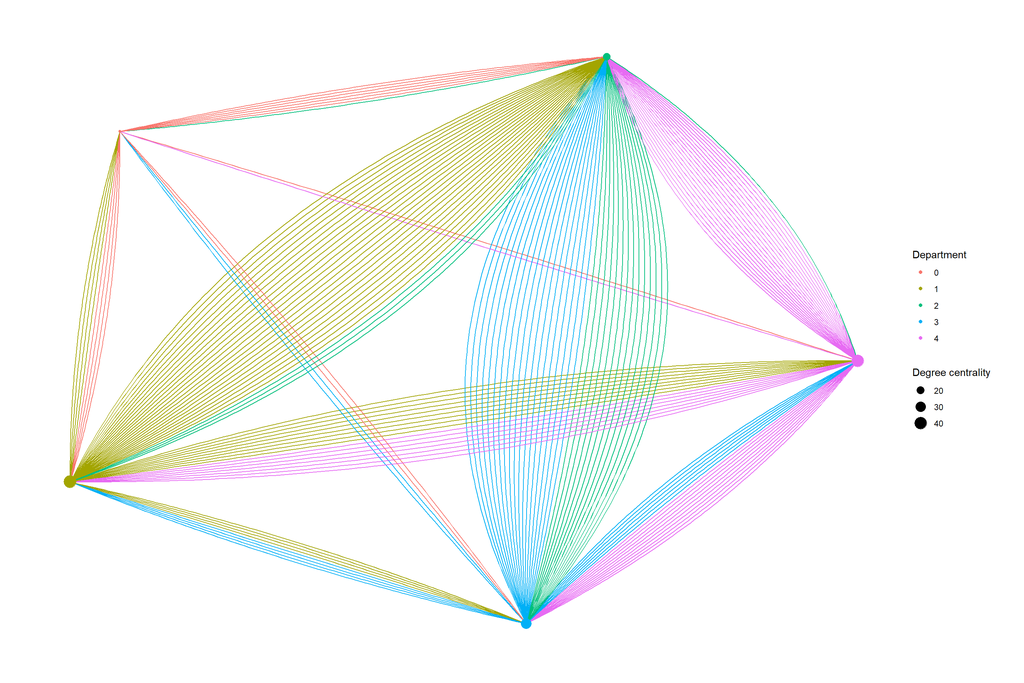

```r
g_adv_dept %>%
  ggraph(layout = "kk") +
  geom_edge_fan(aes(color = as.factor(.N()$name[to])), show.legend = FALSE) + # Coloring edges by which department they are going to.
  geom_node_point(aes(size = centrality_degree(mode = 'in'), color = name)) + # Sizing nodes by degree centrality and coloring them by department.
  labs(color = "Department", size = "Degree centrality") + # Changing labels.
  theme_graph()
```

Admittedly the colors look a bit silly, but they are able to convey where the nodes are going to. There are no loops, so a blue edge arriving to the blue department (3), must come from another department. Based on the visualization department 1 and 4 have the highest in-degree centrality, meaning that the most people go to these departments for advice. We can also see that department 2 and 3 mostly go to eachother for advice. The same procedure is repeated for the friendship edgelist.

```r
friend_dept <- friendship %>%
  left_join(attributes, by = c("from" = "id")) %>%
  left_join(attributes, by = c("to" = "id")) %>%
  select(dept.x,dept.y) # Only selecting the new "from" and "to" columns.

colnames(friend_dept) = c("from", "to") # Renaming the columns.
friend_dept %<>% filter(!from == to)
glimpse(friend_dept)
```

```
## Rows: 64
## Columns: 2
## $ from <int> 4, 4, 4, 4, 4, 4, 4, 2, 2, 2, 2, 1, 1, 1, 1, 3, 3, 3, 3, 3, 3,...
## $ to   <int> 1, 1, 3, 1, 1, 1, 1, 4, 3, 1, 1, 4, 0, 2, 4, 2, 2, 1, 2, 1, 4,...
```

Creating the graph object.

```r
g_friend_dept <- as_tbl_graph(friend_dept, directed = TRUE) # Creating a new directed graph object.
```

Plotting the result.

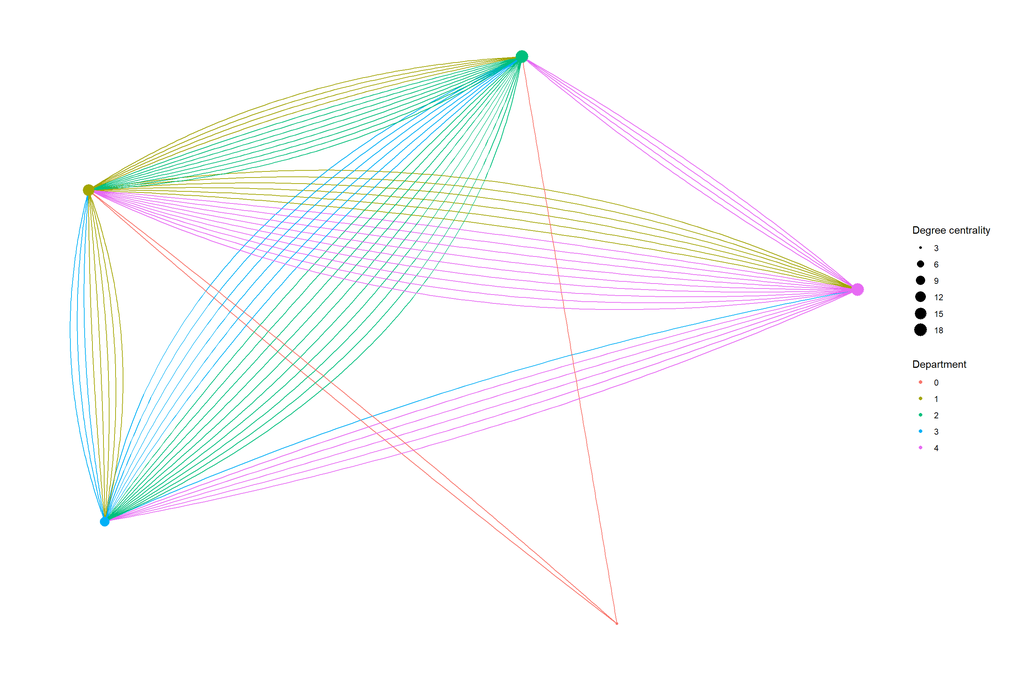

```r
g_friend_dept %>% ggraph(layout = "kk") +
  geom_edge_fan(aes(color = as.factor(.N()$name[to])), show.legend = FALSE) +
  geom_node_point(aes(size = centrality_degree(mode = 'in'), color = name)) +
  labs(color = "Department", size = "Degree centrality") +
  theme_graph()
```

## 4. Visualization

I will try to visualize each of the networks in a comprehensible manner. I will attempt to visualize a reasonable amount of information while the networks are still nice to look at.

#### Visualization of the advice network

First I will be plotting the advice network. Based on the previous exploration of assortativity, I will be using department colors to distinguish the nodes, and where the edges are going. The opacity of edges also determines the direction of the edge, as they will be solid when arriving to their alter and seethrough at their ego. Recall, the assortativity was rather low, but there was a positive effect, which might reveal itself visually. I will also be labeling the nodes by the person id, so the plot is comparable to the exploration of in-degree centrality from earlier. In-degree centrality is also used to scale the nodes, such that more popular nodes are larger.

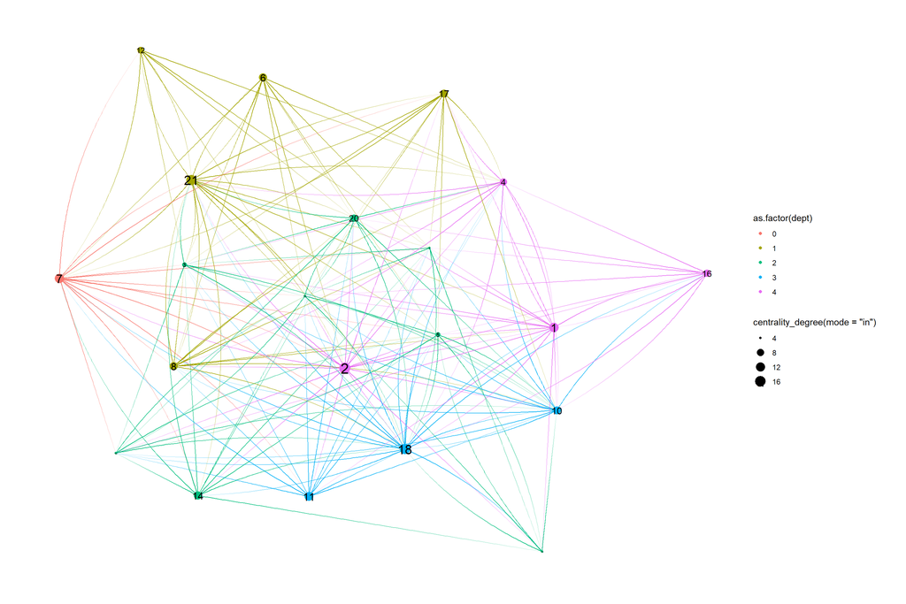

```r
set.seed(42) # Setting a seed to get the same plot every time the code runs.
g_adv %>%
  ggraph(layout = 'kk') +
  geom_edge_fan(aes(color = as.factor(.N()$dept[to]), alpha = stat(index)), show.legend = FALSE) +
  geom_node_point(aes(color = as.factor(dept), size = centrality_degree(mode = "in"))) +
  geom_node_text(aes(label = name, size = centrality_degree(mode = "in"))) + # Adding the person id as a label to the nodes.
  theme_graph()
```

The most central nodes are rather apparent. Person 18, 21 and 2 are the most important in the network, as we saw in the previous task, but it can be seen that 2 differs from the other two advice-givers, in that him/her is sought after by most of the network, and is therefore very central in the plot. General for department 1 is that they do not seek advice from the other departments often, and it seems 21 is usually sought after by their own department for advice. However, as can be seen from the many edges arriving at department 1 nodes, their department is also used by advice-seekers from other departments. The CEO is also noteworthy, as someone who gives alot of advice, but also that he/she has people in every department that they go to for advice.

#### Visualization of the friendship network

The assortativity from earlier suggested a positive effect of employment level on friendship. Because of this I will color the nodes by the employment level, as well as color the edges by the level of the alter. In addition to this the edges also have arrows to indicate their direction. Important nodes are still highlighted by in-degree centrality.

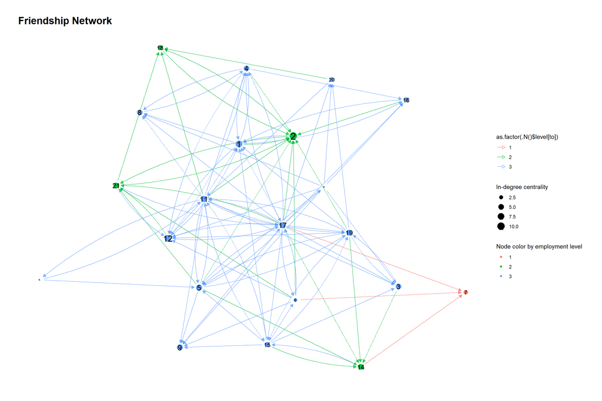

```r
set.seed(42)
g_friend %>%
  ggraph(layout = 'kk') +
  geom_edge_fan(aes(color = as.factor(.N()$level[to])), # coloring edges by level of the "to" node.
                    arrow = arrow(type = "closed",
                        length = unit(2, "mm")),
                        start_cap = circle(3, "mm"),
                        end_cap = circle(3, "mm"),
                        alpha = 0.7) +
  geom_node_point(aes(color = as.factor(level), size = centrality_degree(mode = "in"))) +
  geom_node_text(aes(label = name, size = centrality_degree(mode = "in"))) +
  labs(title = "Friendship Network", color = "Node color by employment level", size = "In-degree centrality") +
  theme_graph()
```

The network seems to reveal why the assortativity of nodes of similar level is positive. Many of the managers of the lowest level (3), considers eachothers friends. They also considers VP’s their friends, but this is rarely mutual. We went over person 2 earlier, and how they only thought of three people as their friend, but it could be demonstrated by all of the VP’s (and especially the CEO). Higher level employees generally do not tend to reciprocate friendships of lower level employees, which seems to be the reasoning for the found assortativity. A mutual friendship appears much more likely between individuals of the same level.

#### Visualization of the reporting network

The “reporting” network can be visualized using the hierarchical level for node coloring, and coloring the edges by the department they are going to. For the size of the nodes I chose alpha centrality, which is a measure of node centrality in a network. I initially used eigen centrality, where the centrality of the node is weighted by the centrality of the connected nodes. This did not give the desired result, since the eigen centrality favored the VP of department 2 over the CEO, for the most central node in the system, because of the department having the most managers. That is a bit misleading since the CEO should be the most important node, as all the VP’s report to him/her. The alpha centrality can be seen as a generalized version of eigenvector centrality for directed graphs.

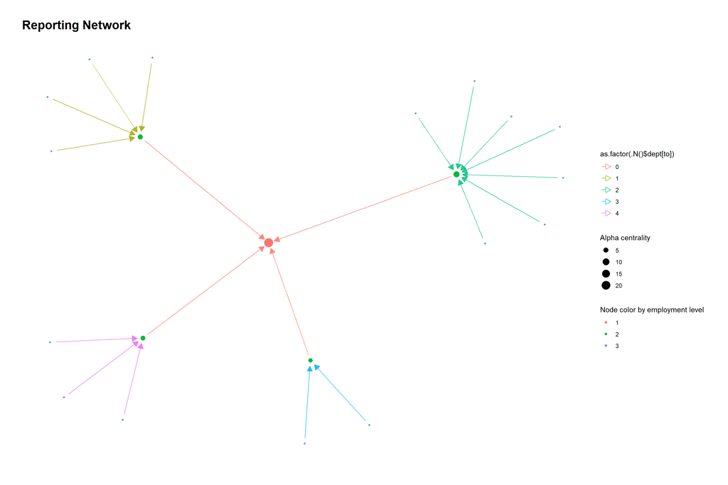

```r
set.seed(42)
g_rep_to %E>%
  ggraph(layout = "nicely") +
    geom_edge_link2(aes(color = as.factor(.N()$dept[to])), # Coloring edges by the community they are going to.
                    arrow = arrow(type = "closed",
                        length = unit(3, "mm")),
                        start_cap = circle(3, "mm"),
                        end_cap = circle(3, "mm"),
                        alpha = 0.8) +
    geom_node_point(aes(col = as.factor(level), size = centrality_alpha())) +
    labs(title = "Reporting Network", color = "Node color by employment level", size = "Alpha centrality") +
    theme_graph()
```

The network clearly displays how the different departments are organized. The level 3 managers report to the VP and the VP of each department reports to the CEO. The alpha centrality did well at distinguishing the most important nodes in the network, as the CEO is the most important and the VP of department 2 is the second-most important, as they manage the most people.